# Homework 8

Yiming Gao (NetID: yimingg2)

2017/4/2

# Exercise 1

For this exercise we will create data via simulation, then asses how well certain methods perform. Use the code below to create a train and test dataset.

```r
library(mlbench)
set.seed(42)
sim_trn = mlbench.spirals(n = 5000, cycles = 1.5, sd = 0.15)
sim_trn = data.frame(sim_trn$x, class = as.factor(sim_trn$classes))
sim_tst = mlbench.spirals(n = 10000, cycles = 1.5, sd = 0.15)
sim_tst = data.frame(sim_tst$x, class = as.factor(sim_tst$classes))
```

The training data is plotted below, with colors indicating the `class` variable, which is the response.

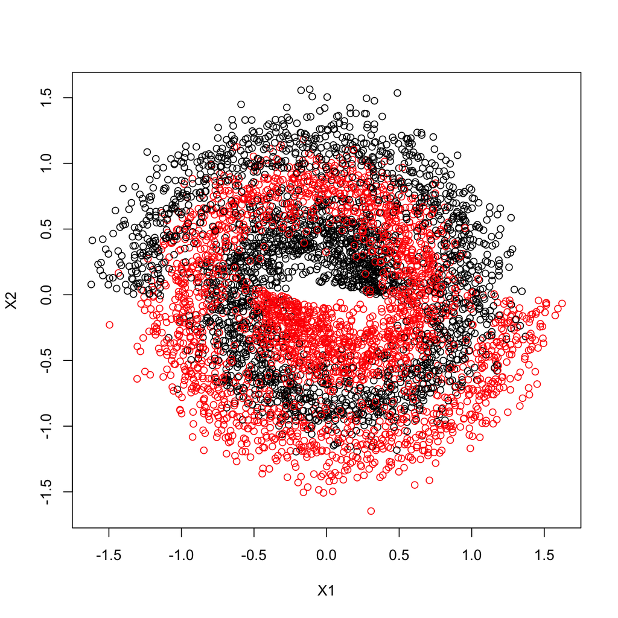

```r
plot(sim_trn$X1, sim_trn$X2, col = sim_trn$class,
     xlab = "X1", ylab = "X2")
```

Before proceeding further, set a seed equal to your UIN.

```r
uin = 650379994
set.seed(uin)
```

We’ll use the following to define 5-fold cross-validation for use with `train()` from `caret`.

```r
library(caret)
cv_5 = trainControl(method = "cv", number = 5)
oob = trainControl(method = "oob")
```

Repeat the above analysis using a random forest, twice. The first time use 5-fold cross-validation. The second time, tune the model using OOB samples. We only have two predictors here, so, for both, use the following tuning grid.

First we set up some helper functions.

```r
# accuracy function
accuracy = function(actual, predicted) {
  mean(actual == predicted)
}

# rmse function
rmse = function(actual, predicted) {
  sqrt(mean((actual - predicted) ^ 2))
}

get_rmse = function(model, data, response) {
  rmse(actual = data[, response],
       predicted = predict(model, data))
}

# extract the row with the best tuning parameters
get_best_result = function(caret_fit) {
  best_result = caret_fit$results[as.numeric(rownames(caret_fit$bestTune)), ]
  rownames(best_result) = NULL
  best_result
}
```

```r
rf_grid = expand.grid(mtry = c(1, 2))
```

We specify `verbose = FALSE` to suppress the output related to progress. `mtry` values include all possible values of predictors, here is 2.

```r
# question a
# 5-fold cross-validation
rf_cv_time = system.time({
  sim_rf_cv  = train(
    class ~ ., data = sim_trn,
    trControl = cv_5,
    verbose = FALSE,
    method = "rf",
    tuneGrid = rf_grid)
})

# oob
rf_oob_time = system.time({
  sim_rf_oob  = train(
    class ~ ., data = sim_trn,
    trControl = oob,
    verbose = FALSE,
    method = "rf",
    tuneGrid = rf_grid)
})
```

### Problem a

```r
# system time
rf_cv_time["elapsed"]
```

```
## elapsed
##  17.228
```

```r
rf_oob_time["elapsed"]
```

```
## elapsed
##   5.279
```

In random forests, the test error is estimated internally, i.e. OOB error rate.

> Each tree is constructed using a different bootstrap sample from the original data. About one-third of the cases are left out of the bootstrap sample and not used in the construction of the kth tree. In this way, a test set classification is obtained for each case in about one-third of the trees.

In this problem, oob runs **faster** than cv, which is what we expect.

### Problem b

```r
# question b
# cv
sim_rf_cv_best = get_best_result(sim_rf_cv)

# oob
sim_rf_oob_best = get_best_result(sim_rf_oob)

sim_rf_cv_best
```

```
##   mtry Accuracy  Kappa AccuracySD    KappaSD
## 1    1   0.7734 0.5468 0.01180254 0.02360508
```

```r
sim_rf_oob_best
```

```
##   Accuracy  Kappa mtry
## 1   0.7706 0.5412    1
```

### Problem c

```r
# question c
sim_rf_cv_acc = sim_rf_cv_best$Accuracy #cv

sim_rf_oob_acc = sim_rf_oob_best$Accuracy # oob
```

### Problem d

```r
# question d
sim_rf_cv_tst_acc = accuracy(predict(sim_rf_cv, newdata = sim_tst),
                             sim_tst$class) # cv test accuracy

sim_rf_oob_tst_acc = accuracy(predict(sim_rf_oob, newdata = sim_tst),
                              sim_tst$class) # oob test accuracy
```

**(a)** Compare the time taken to tune each model. Is the difference between the OOB and CV result for the random forest similar to what you would have expected?

- I expect **cross-validated** random forest to take more time. And the result is that OOB takes 5.279 seconds, which is much less than CV method (17.228) takes.

**(b)** Compare the tuned value of `mtry` for each of the random forests tuned. Do they choose the same model?

- CV random forest returns the best tuned value for `mtry` is 1, which is the same as OOB random forest gives.

**(c)** Report the CV and OOB accuracy for the random forests.

- See below.

**(d)** Compare the test accuracy of each of the four procedures considered. Briefly explain these results.

- See below.

We summarize the results into following table:

| Method | Parameter | Parameter Value | Accuracy | Test Accuracy |
| --- | --- | --- | --- | --- |
| 5-fold Cross Validation | `mtry` | 1 | 0.7734 | 0.7772 |
| Out of Bag | `mtry` | 1 | 0.7706 | 0.7790 |

# Exercise 2

After changing `uin` to your UIN, use the following code to test-train split the data.

```r
uin = 650379994
set.seed(uin)
hit_idx = createDataPartition(Hitters$Salary, p = 0.6, list = FALSE)
hit_trn = Hitters[hit_idx,]
hit_tst = Hitters[-hit_idx,]
```

### Problem a

Tune a boosted tree model using the following tuning grid and 5-fold cross-validation. Create a plot that shows the tuning results.

```r
gbm_grid = expand.grid(interaction.depth = c(1, 2),
                       n.trees = c(500, 1000, 1500),
                       shrinkage = c(0.001, 0.01, 0.1),
                       n.minobsinnode = 10)

# boosted tree model
hit_gbm_cv = train(Salary ~ ., data = hit_trn,
                  method = "gbm",
                  trControl = cv_5,
                  verbose = FALSE,
                  tuneGrid = gbm_grid)
```

Then we plot the results.

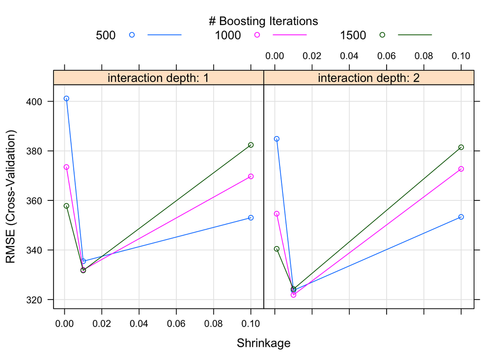

```r
plot(hit_gbm_cv)
```

### Problem b

What is the CV-RMSE and tuning parameters of the tuned boosted tree model?

```r
hit_gbm_best = get_best_result(hit_gbm_cv)
hit_gbm_best
```

```
##   shrinkage interaction.depth n.minobsinnode n.trees     RMSE  Rsquared
## 1      0.01                 2             10    1000 321.8556 0.5464725
##    RMSESD RsquaredSD
## 1 86.4602 0.09816625
```

From the output, we know that the CV-RMSE is 321.8556. And the returned tuning parameters are interaction.depth = 2, n.trees = 1000, shrinkage = 0.01 and n.minobsinnode = 10.

### Problem c

According to the boosted model, what are the two most important predictors?

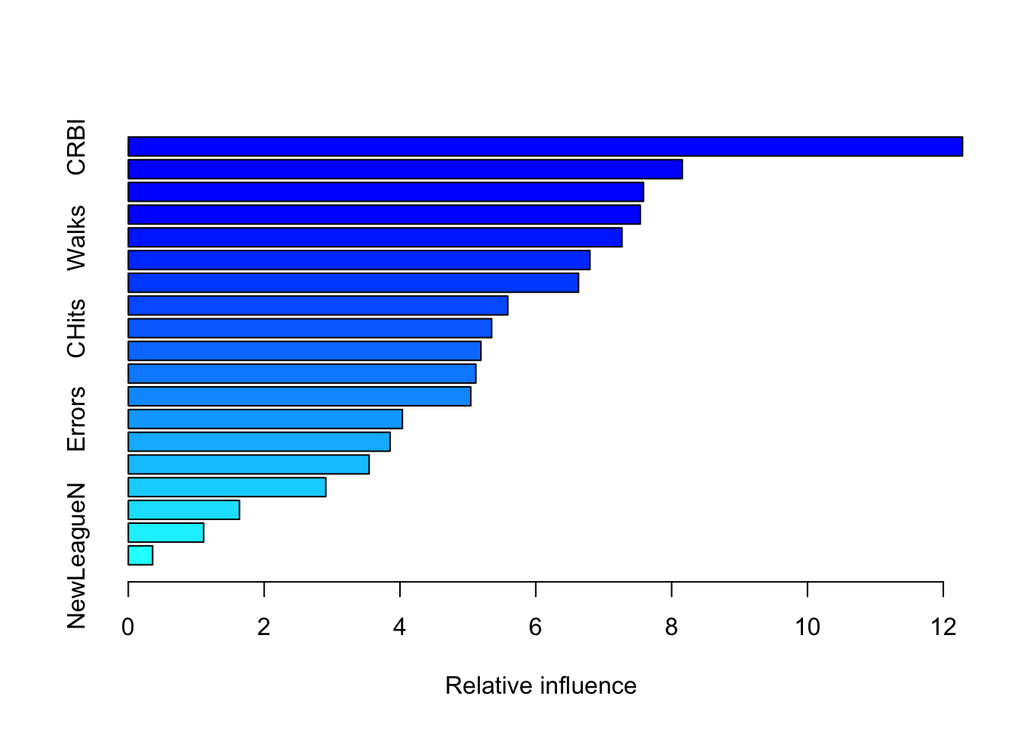

```
##       var   rel.inf
## CRBI CRBI 12.283406
## Hits Hits  8.156949
```

```r
summary(hit_gbm_cv)[1:2, ]
```

From the output above, we know that the two most important predictors are CRBI and Hits.

### Problem d

Tune a random forest using OOB resampling and **all** possible values of `mtry`. Report the best value of `mtry` as well as the OOB RMSE for both the best model as well as the bagged model.

We setup a grid of mtry values which include all possible values since there are 19 predictors in the dataset. Bagging is actually a special case of a random forest where `mtry` is equal to 19, the number of predictors.

```r
rf_grid =  expand.grid(mtry = 1: (ncol(hit_trn) - 1))

# oob
hit_rf_oob = train(
  Salary ~ ., data = hit_trn,
  trControl = oob,
  verbose = FALSE,
  method = "rf",
  tuneGrid = rf_grid)

# rf oob best
hit_rf_oob_best = get_best_result(hit_rf_oob)
hit_rf_oob_best
```

```
##       RMSE  Rsquared mtry
## 1 298.2727 0.5757397    7
```

```r
# bagged model
hit_bagged = hit_rf_oob$results[ncol(hit_trn) - 1, ]
hit_bagged
```

```
##        RMSE  Rsquared mtry
## 19 302.8418 0.5626423   19
```

The best value of `mtry` is 7 and the corresponding OOB RMSE is 298.2727.

The OOB RMSE for bagged model is 302.8418. They are not the same model.

### Problem e

Report the test RMSE for the tuned boosted tree model, the tuned random forest, and a bagged tree model.

```r
# tuned boosted tree model
hit_gbm_tst_rmse = get_rmse(hit_gbm_cv, data = hit_tst, response = "Salary")

# tuned random forest model
hit_rf_oob_tst_rmse = get_rmse(hit_rf_oob, data = hit_tst, response = "Salary")

# bagged tree model
hit_bagged = randomForest(Salary ~ ., data = hit_trn, mtry = 19)
hit_bagged_tst_rmse = get_rmse(hit_bagged, data = hit_tst, response = "Salary")
```

We summarize the results into following table:

| Model | Test RMSE |
| --- | --- |
| Tuned boosted tree model | 251.1064 |
| Tuned random forest | 255.4916 |
| Bagged tree model | 256.1704 |

# Exercise 3

Continue with the data from Exercise 2. The book, ISL, suggests log transforming the response, `Salary`, before fitting a random forest. Is this necessary? Re-tune a random forest as you did in Exercise 2, except with a log transformed response. Report test RMSE for both the untransformed and transformed model. Based on these results, do you think the transformation was necessary?

We first visualize the transformed response.

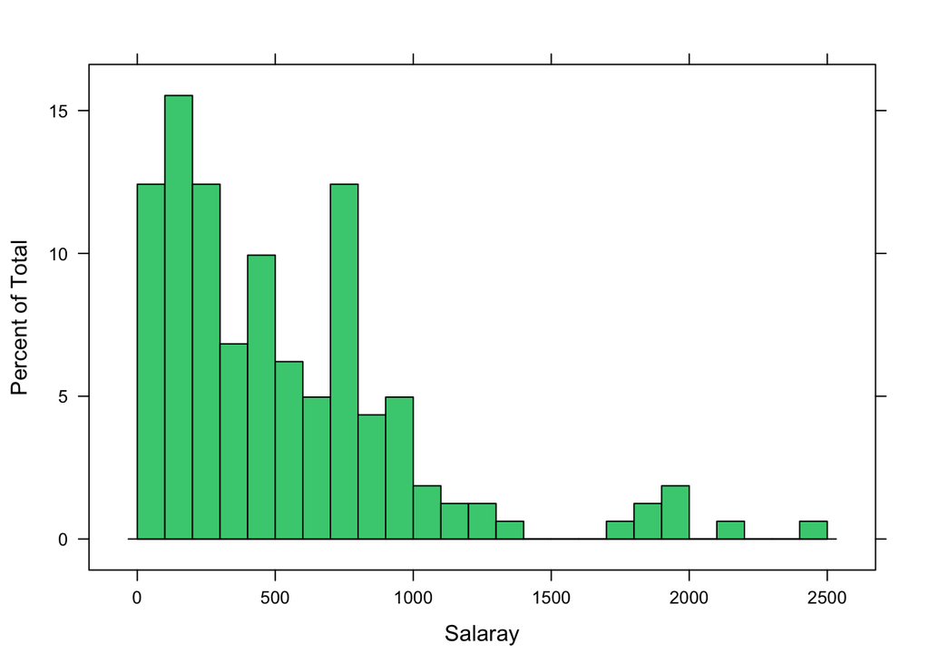

```r
histogram(hit_trn$Salary, xlab = "Salaray", breaks = 20, col = "seagreen3")
```

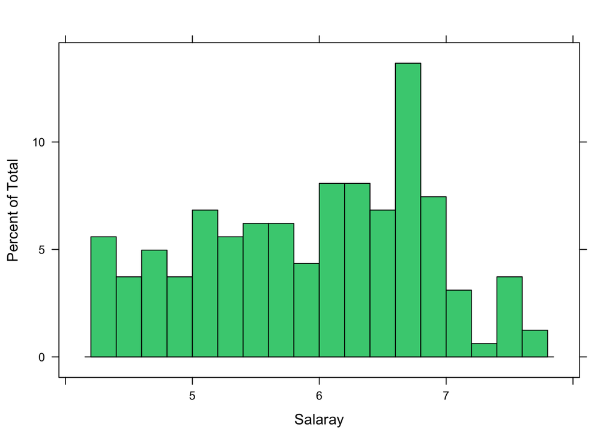

```r
histogram(log(hit_trn$Salary), xlab = "Salaray", breaks = 25, col = "seagreen3")
```

```r
rf_grid =  expand.grid(mtry = 1: 19)

# oob
hit_rf_log = train(
  log(Salary) ~ ., data = hit_trn,
  trControl = oob,
  verbose = FALSE,
  method = "rf",
  tuneGrid = rf_grid)

# bestTune after log transformation
hit_rf_log_best = get_best_result(hit_rf_log)

# test RMSE
hit_rf_log_tst_rmse = get_rmse(hit_rf_log, data = hit_tst, response = "Salary")

# return back to original unit
hit_rf_log_tst_rmse = rmse(actual = hit_tst[, "Salary"],
                           predicted = exp(predict(hit_rf_log, hit_tst)))
```

We summarize the results into following table:

| Model | Test RMSE |
| --- | --- |
| Untransformed RF model | 255.4916 |
| Transformed RF model | 265.2886 |

We see that the test RMSE becomes even higher for transformed model, so I don’t think it necessary to transform the data.